# 01_datawrangling

Lena Kuschel

13 October 2020

## Library

```r
library(car)
library(psych)
```

```r
library(ggplot2)
library(formr)
library(codebook)
library(dplyr)
```

## Data

Load selected data based on 00_dataimport

```r
fulldata_selected = read.csv(file = "fulldata_selected.csv")[,-1]
```

## Inspect Data

```r
colnames(fulldata_selected)
```

```
##  [1] "political_orientation"          "age"
##  [3] "interest_single"                "interest_sexrel"
##  [5] "interest_nonmonrel"             "inteterst_monrel"
##  [7] "pref_politicalsim"              "pref_ethnicalsim"
##  [9] "pref_religioussim"              "pref_level_kind"
## [11] "pref_level_supportive"          "pref_level_attractive_body"
## [13] "pref_level_attractive_face"     "pref_level_financially_secure"
## [15] "pref_level_successful_ambitous" "pref_level_confident"
## [17] "pref_level_assertive"           "pref_level_intelligence"
## [19] "pref_level_educated"            "imp_age"
## [21] "ideal_age"                      "imp_height"
## [23] "ideal_height"                   "country"
## [25] "language"                       "sex"
## [27] "sexual_orientation"             "relationship"
## [29] "relationship1"                  "relationship2"
## [31] "relationship3"                  "relationship4"
## [33] "relationship5"                  "answer_accuracy"
```

```r
fulldata_selected_wrangled = fulldata_selected
```

Correct typo in variable pref_level_successful_ambitious

```r
fulldata_selected_wrangled <- rename(fulldata_selected_wrangled, pref_level_successful_ambitious= pref_level_successful_ambitous)
```

Correct typo in variable interest_monrel

```r
fulldata_selected_wrangled <- rename(fulldata_selected_wrangled, interest_monrel = inteterst_monrel)
```

### Age

Participants younger than 18 were able to insert age but the survey was ended for them afterwards.

```r
table(fulldata_selected_wrangled$age)
```

```
##
##          0          1          2          5          8         10         11
##         12          5          4          2          1         13        121
##         12         13         14         15         16         17         18
##        615       1701       3225       5361       7594       7984      14137
##         19         20         21         22         23         24         25
##       6613       5217       4535       3753       3341       2997       2833
##         26         27         28         29         30         31         32
##       2619       2432       2275       2022       1917       1578       1483
##         33         34         35         36         37         38         39
##       1265       1152       1052        949        779        721        607
##         40         41         42         43         44         45         46
##        610        464        494        408        323        317        231
##         47         48         49         50         51         52         53
##        214        167        112        103         61         57         30
##         54         55         56         57         58         59         60
##         27         32         20         15         16          8         12
##         61         62         63         64         65         66         67
##          5          6          8         11          5         11          6
##         68         69         70         71         73         75         76
##          7          3          8          6          2          2          1
##         77         78         80         85        100        111        116
##          1          2          1          1          1          1          1
##        160        175        183        210        222        223        247
##          1          1          1          1          1          1          1
##        293        447        789       1516   36015310 5090897866
##          1          1          1          1          1          1
```

Set all numbers > 100 as missing:

```r
sum(fulldata_selected_wrangled$age > 100)
```

```
## [1] 15
```

```r
# This means that age is set as missing for 15 people

fulldata_selected_wrangled = fulldata_selected_wrangled %>%
  mutate(age = ifelse(age > 100, NA, age))

table(is.na(fulldata_selected_wrangled$age))
```

```
##
## FALSE  TRUE
## 94723    15
```

```r
table(fulldata_selected_wrangled$age < 18)
```

```
##
## FALSE  TRUE
## 68085 26638
```

```r
# 26638 people were not allowed to participate in the survey because they were younger than 18
```

### Political Orientation

Political Orientation item should range from 0 to 6

```r
fulldata_selected_wrangled %>%
  select("political_orientation") %>%
  lapply(table)
```

```
## $political_orientation
##
##     0     1     2     3     4     5     6
##  6354  8870 11049 18306  5148  1984  1364
```

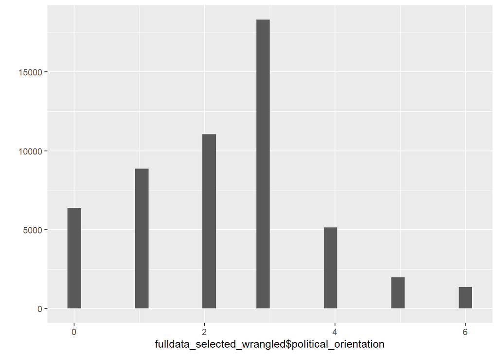

```r
qplot(fulldata_selected_wrangled$political_orientation)
```

### Preferred Relationship Options

Interest in being single, interest in sexual (non-romantic) relationships, interest in non-monogamous relationships and interest in monogamous relationships items should range from 0 to 6

```r
fulldata_selected_wrangled %>%
  select(starts_with("interest_")) %>%
  lapply(table)
```

```
## $interest_single
##
##     0     1     2     3     4     5     6     7
## 16963  7793  8019 10533  5468  2802  1992    27
##
## $interest_sexrel
##
##     0     1     2     3     4     5     6     7
## 18250  6698  7139  8129  5613  3453  3583   717
##
## $interest_nonmonrel
##
##     0     1     2     3     4     5     6     7
## 31167  6682  4377  4681  2763  1666  2072    27
##
## $interest_monrel
##
##     0     1     2     3     4     5     6     7
##  3613  1080  1419  4214  5672  9668 26965   842
```

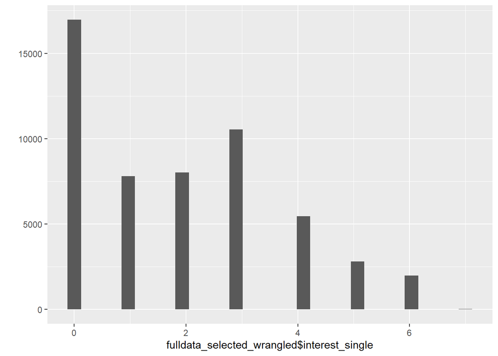

```r
qplot(fulldata_selected_wrangled$interest_single)
```

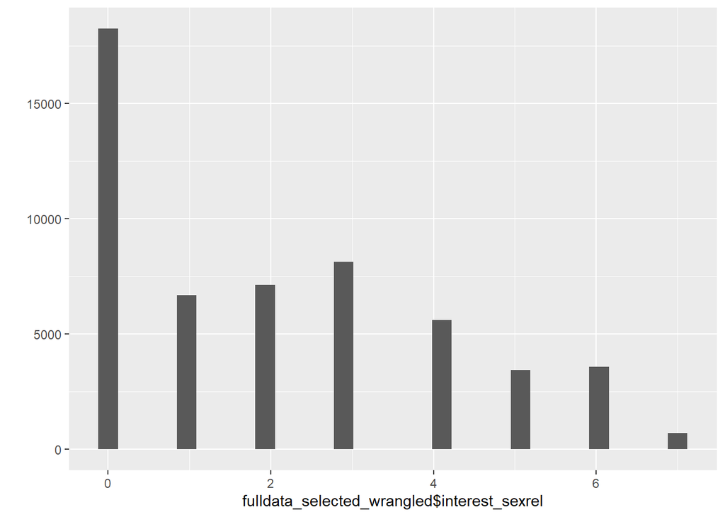

```r
qplot(fulldata_selected_wrangled$interest_sexrel)
```

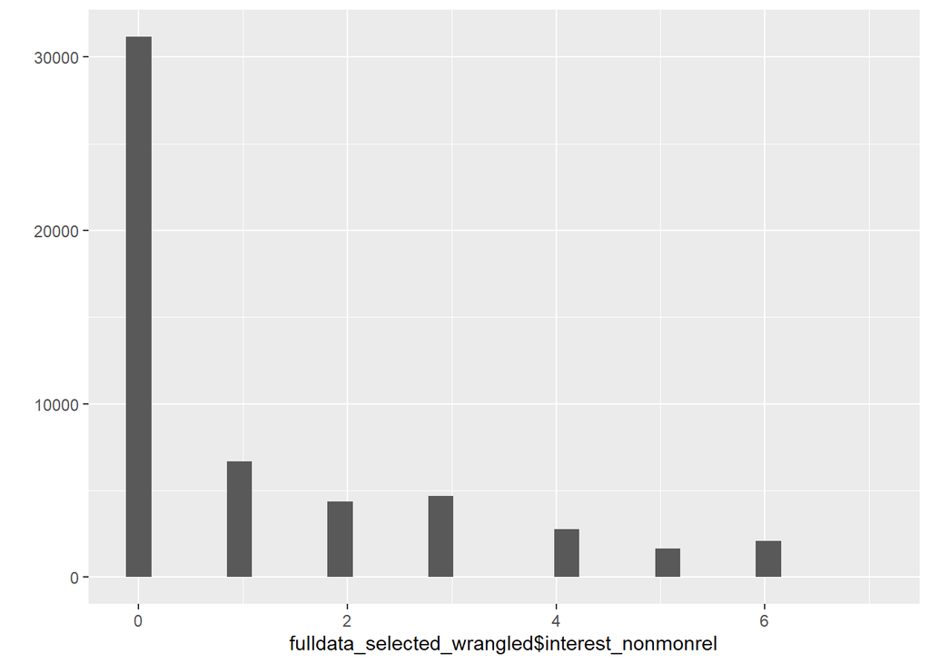

```r
qplot(fulldata_selected_wrangled$interest_nonmonrel)
```

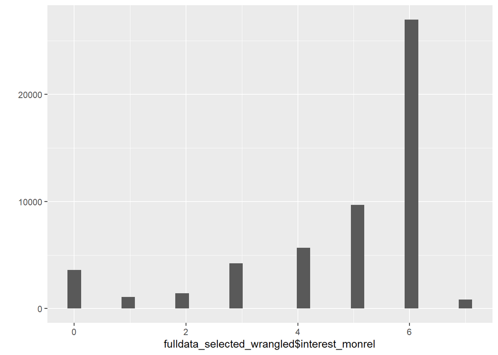

```r
qplot(fulldata_selected_wrangled$interest_monrel)
```

### Political, ethnical, religious similarity

Preferences for political, ethnical and religious similarity items should range from 0 to 6

```r
fulldata_selected_wrangled %>%
  select("pref_politicalsim", "pref_ethnicalsim", "pref_religioussim") %>%
  lapply(table)
```

```
## $pref_politicalsim
##
##     0     1     2     3     4     5     6
## 10261  3146  5875 11468 12349 10190  8242
##
## $pref_ethnicalsim
##
##     0     1     2     3     4     5     6
##  2068  2387  3579 15778  6382  3748  2926
##
## $pref_religioussim
##
##     0     1     2     3     4     5     6
## 17076  4528  6521  9558  8245  6440  9137
```

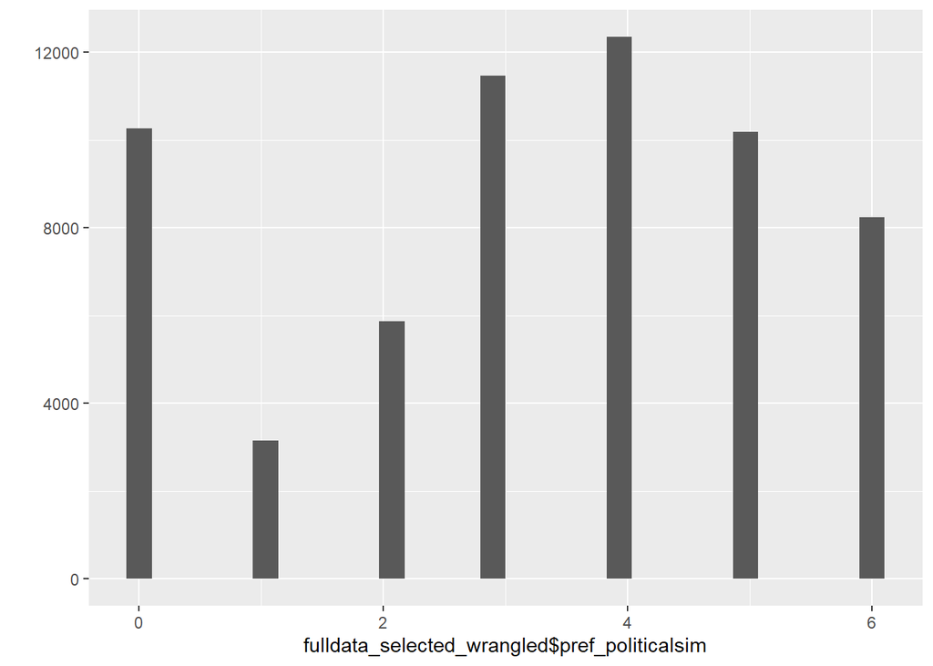

```r
qplot(fulldata_selected_wrangled$pref_politicalsim)
```

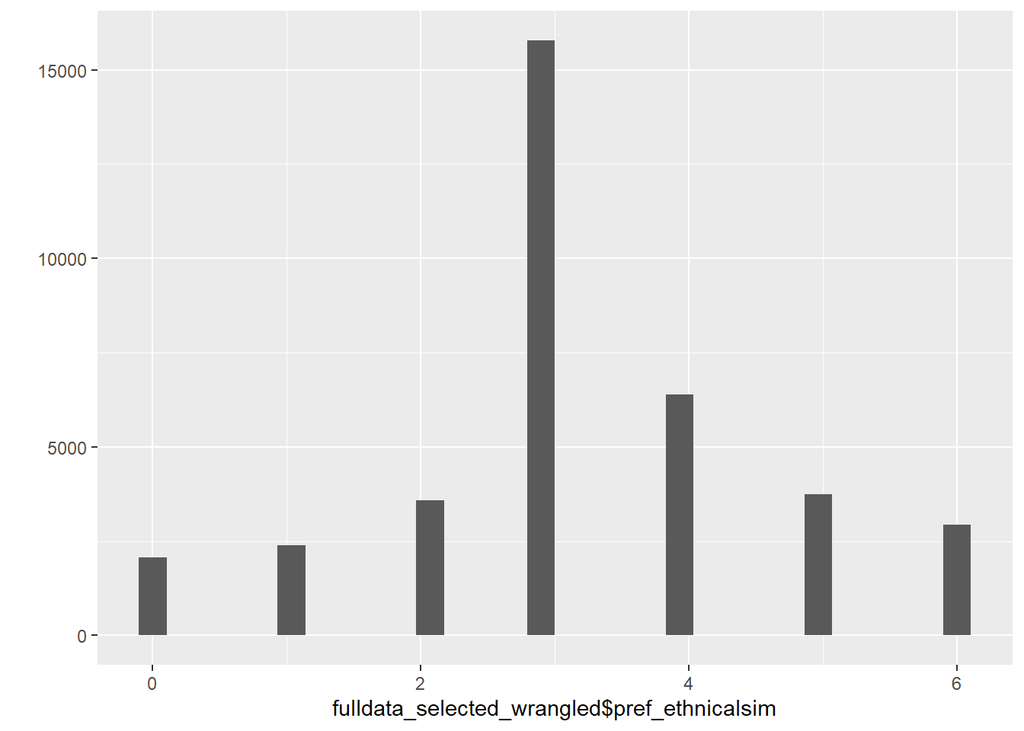

```r
qplot(fulldata_selected_wrangled$pref_ethnicalsim)
```

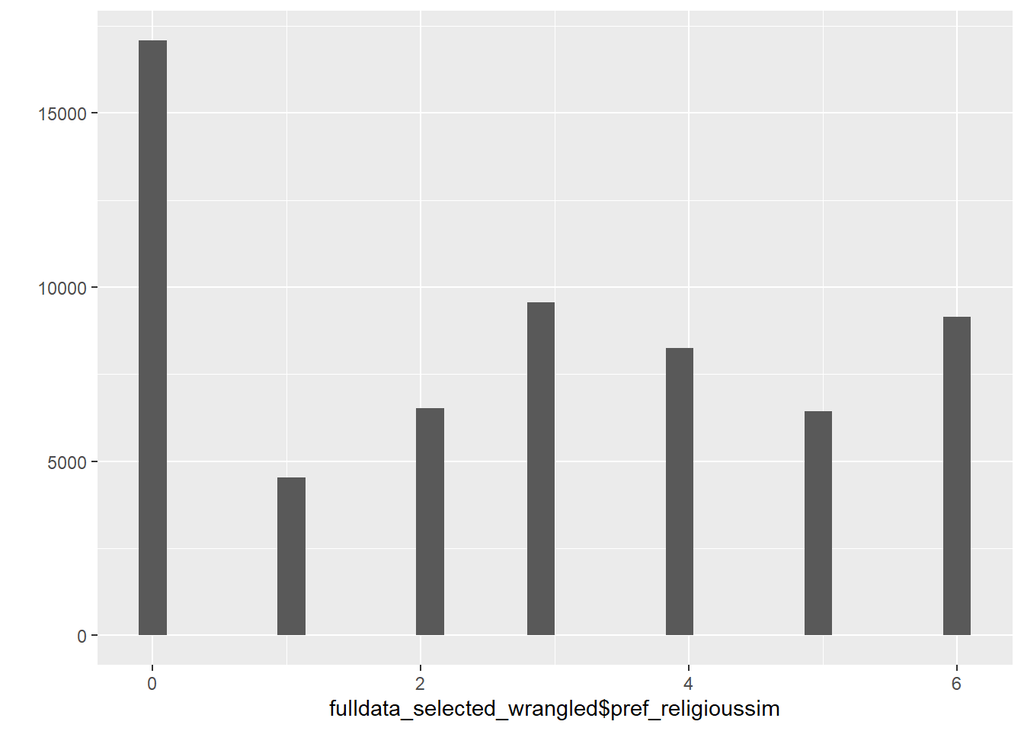

```r
qplot(fulldata_selected_wrangled$pref_religioussim)
```

### Ideal Partner Preferences

All ideal partner preference items should range from 0 to 6

```r
fulldata_selected_wrangled %>%
  select(starts_with("pref_")) %>%
  select(-pref_politicalsim, -pref_ethnicalsim, -pref_religioussim) %>%
  lapply(table)
```

```
## $pref_level_kind
##
##     0     1     2     3     4     5     6
##     9    29   193  1713  9293 20726 32604
##
## $pref_level_supportive
##
##     0     1     2     3     4     5     6
##    22    41   204  2202 13705 23723 24858
##
## $pref_level_attractive_body
##
##     0     1     2     3     4     5     6
##   167  1024  4285 19092 24097 10152  3306
##
## $pref_level_attractive_face
##
##     0     1     2     3     4     5     6
##    77   747  2617 12363 22965 17006  7027
##
## $pref_level_financially_secure
##
##     0     1     2     3     4     5     6
##   213   739  2885 13220 21693 15961  7915
##
## $pref_level_successful_ambitious
##
##     0     1     2     3     4     5     6
##   111   495  1988 10604 22153 17865 10877
##
## $pref_level_confident
##
##     0     1     2     3     4     5     6
##    24   138   853  7622 21269 17942 16707
##
## $pref_level_assertive
##
##     0     1     2     3     4     5     6
##   119   482  2492 15755 25253 14572  5786
##
## $pref_level_intelligence
##
##     0     1     2     3     4     5     6
##    18    76   347  4461 18515 25057 16041
##
## $pref_level_educated
##
##     0     1     2     3     4     5     6
##   112   299  1198  7865 19824 19876 14603
```

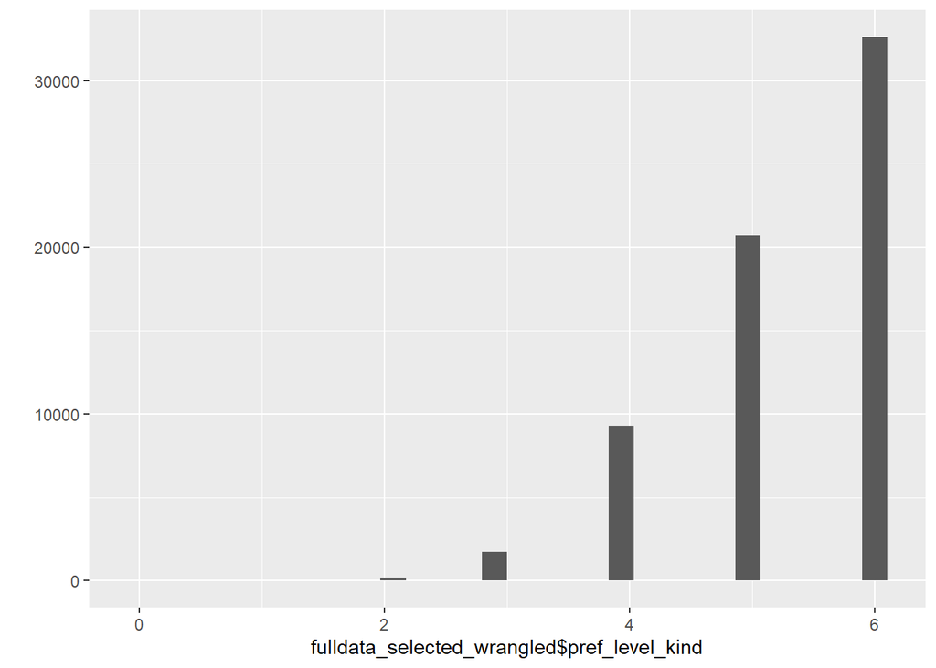

```r
qplot(fulldata_selected_wrangled$pref_level_kind)
```

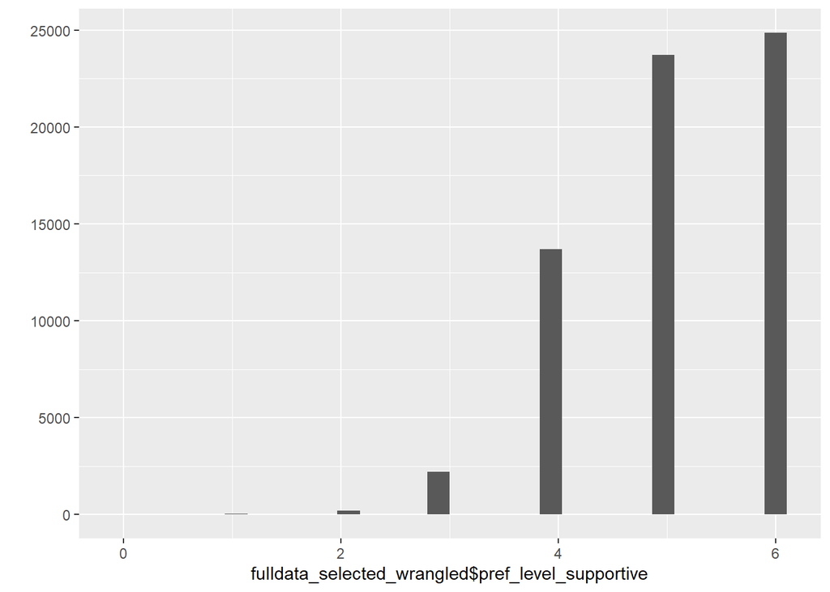

```r
qplot(fulldata_selected_wrangled$pref_level_supportive)
```

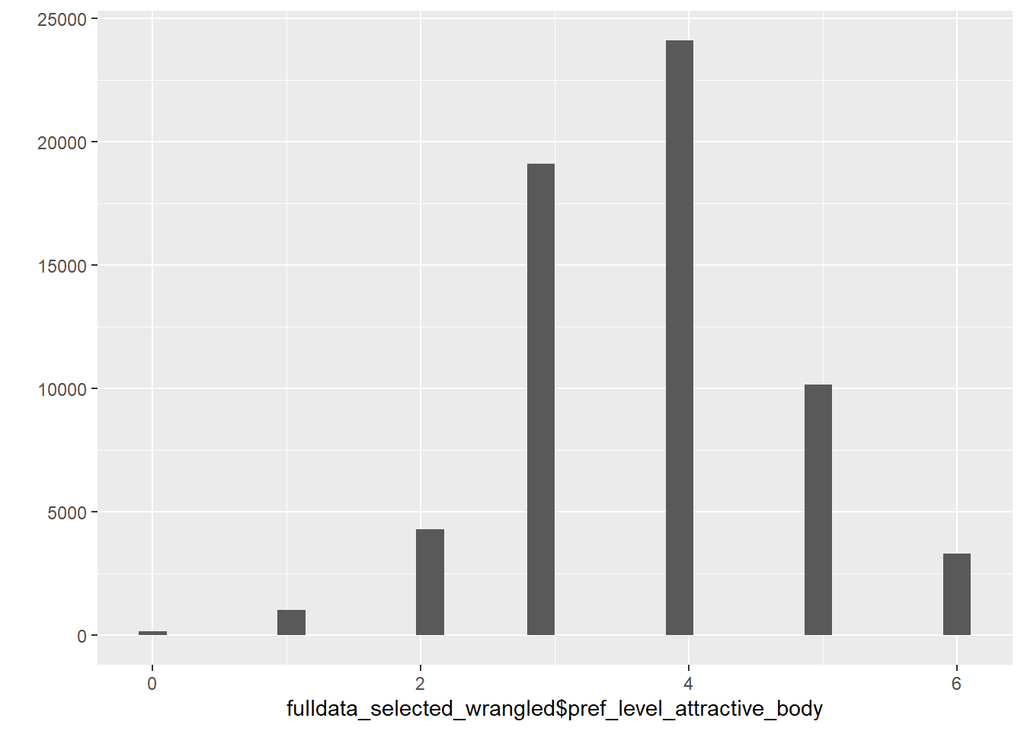

```r
qplot(fulldata_selected_wrangled$pref_level_attractive_body)
```

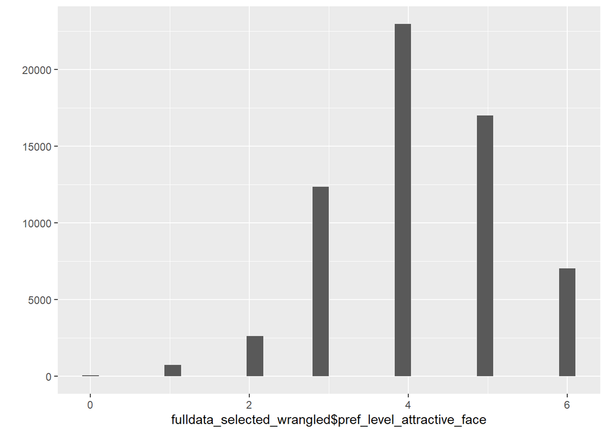

```r
qplot(fulldata_selected_wrangled$pref_level_attractive_face)
```

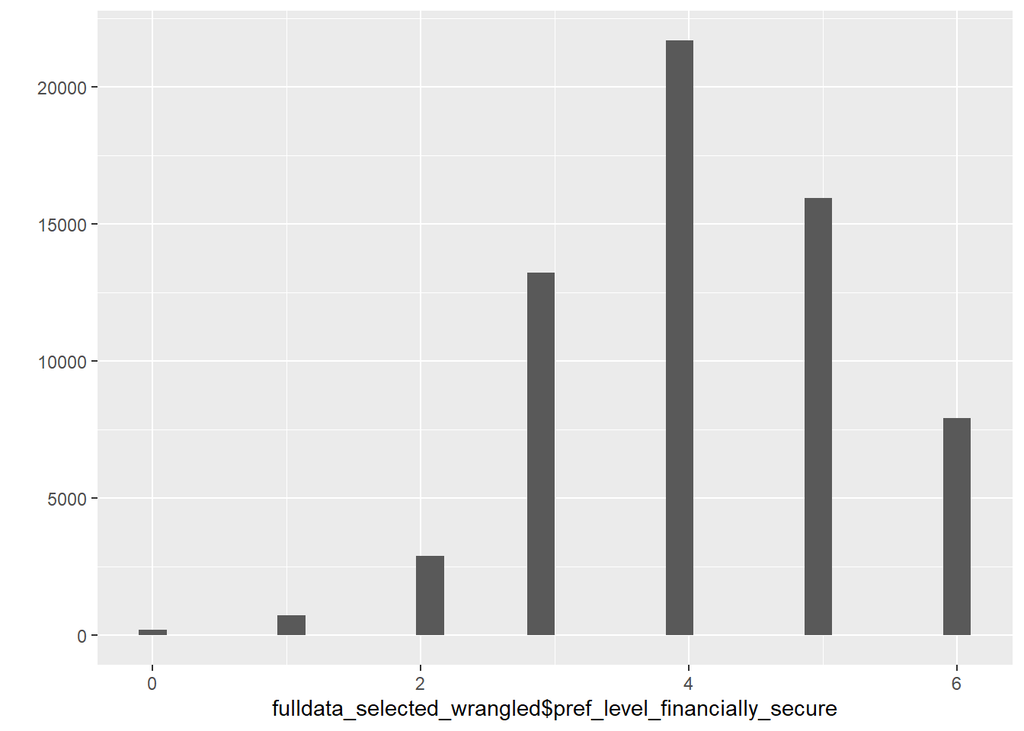

```r
qplot(fulldata_selected_wrangled$pref_level_financially_secure)
```

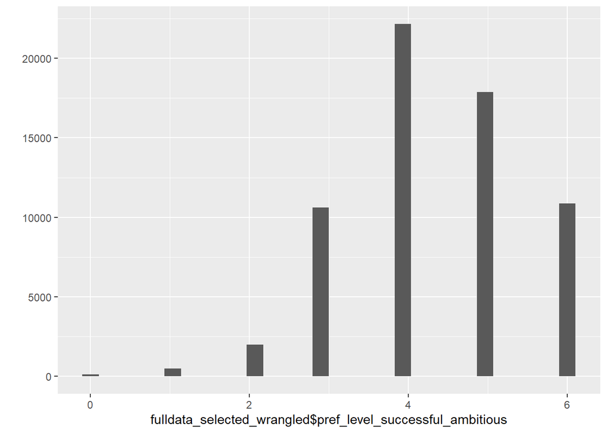

```r
qplot(fulldata_selected_wrangled$pref_level_successful_ambitious)
```

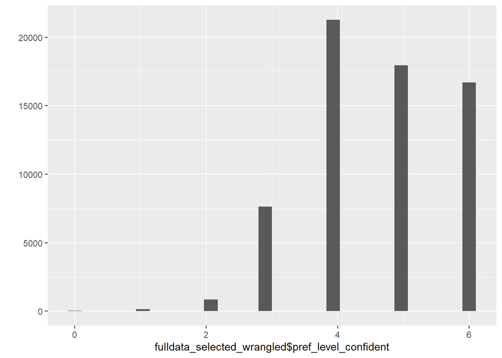

```r
qplot(fulldata_selected_wrangled$pref_level_confident)
```

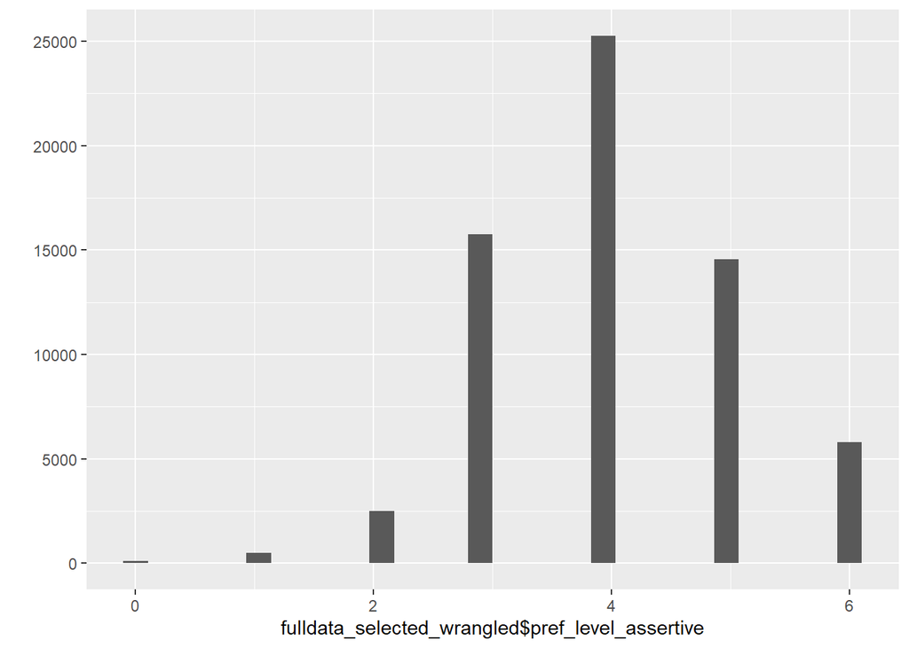

```r
qplot(fulldata_selected_wrangled$pref_level_assertive)
```

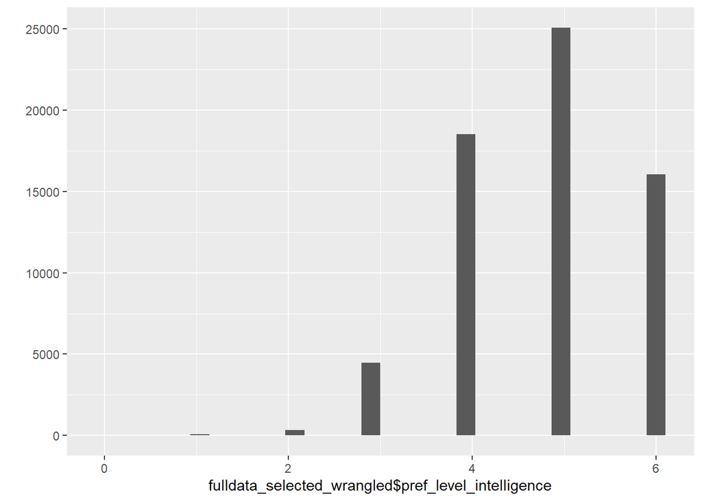

```r
qplot(fulldata_selected_wrangled$pref_level_intelligence)
```

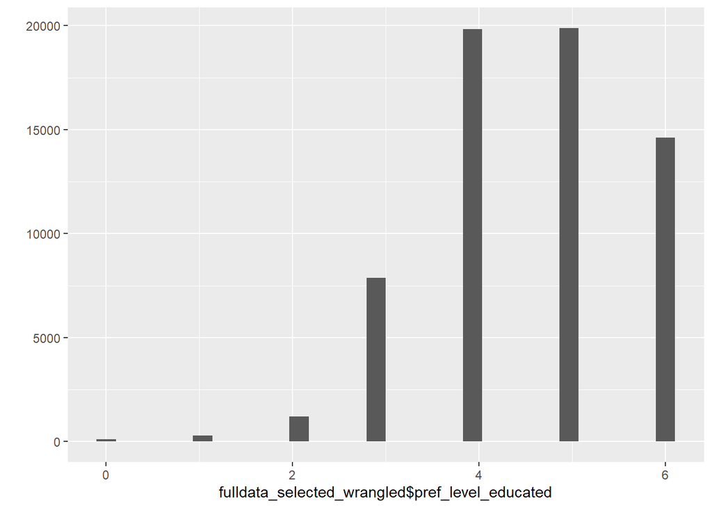

```r
qplot(fulldata_selected_wrangled$pref_level_educated)
```

```r
fulldata_selected_wrangled %>%
  select(starts_with("pref_")) %>%
  select(-pref_politicalsim, -pref_ethnicalsim, -pref_religioussim) %>%
  md_pattern()
```

```
## # A tibble: 6 x 13
##   description pref_level_supp~ pref_level_kind pref_level_conf~ pref_level_inte~
##   <chr>                  <dbl>           <dbl>            <dbl>            <dbl>
## 1 Missing va~            29983           30171            30183            30223
## 2 Missing va~                1               1                1                1
## 3 Missing va~                0               0                0                0
## 4 Missing va~                1               1                1                1
## 5 Missing va~                1               1                1                1
## 6 298 other,~              206             208              186              181
## # ... with 8 more variables: pref_level_assertive <dbl>,
## #   pref_level_successful_ambitious <dbl>, pref_level_educated <dbl>,
## #   pref_level_attractive_face <dbl>, pref_level_financially_secure <dbl>,
## #   pref_level_attractive_body <dbl>, var_miss <dbl>, n_miss <dbl>
```

### Ideal Age and Ideal Height

## Importance Age

Item should range from 0 to 6

```r
fulldata_selected_wrangled %>%
  select("imp_age") %>%
  lapply(table)
```

```
## $imp_age
##
##     0     1     2     3     4     5     6
##  3289  2823  6362 12278 16690  7816  3978
```

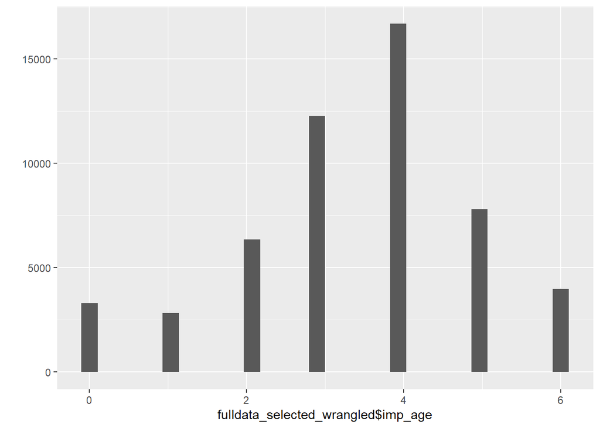

```r
qplot(fulldata_selected_wrangled$imp_age)
```

## Ideal Age

This item is in open format style

```r
fulldata_selected_wrangled %>%
  select("ideal_age") %>%
  lapply(table)
```

```
## $ideal_age
##
##    0   10   11   12   13   14   15   16   17   18   19   20   21   22   23   24
##    1  161    4   12    5   12   25   82  197 2184 2996 4294 2805 3040 2811 2238
##   25   26   27   28   29   30   31   32   33   34   35   36   37   38   39   40
## 3879 2031 1939 2497 1076 3399  685 1463 1069  679 2183  674  507  796  240 1179
##   41   42   43   44   45   46   47   48   49   50   51   52   53   54   55   56
##  142  350  266  173  698  134  116  174   51  288   24   56   32   15   77   15
##   57   58   59   60   62   64   65   67   68   69   70   71   75   77   80   85
##   10   15    3   24    6    2    6    2    3    2    3    2    1    1    1    1
##   88   90   92   96   98   99  100
##    1    1    1    1    1    1   11
```

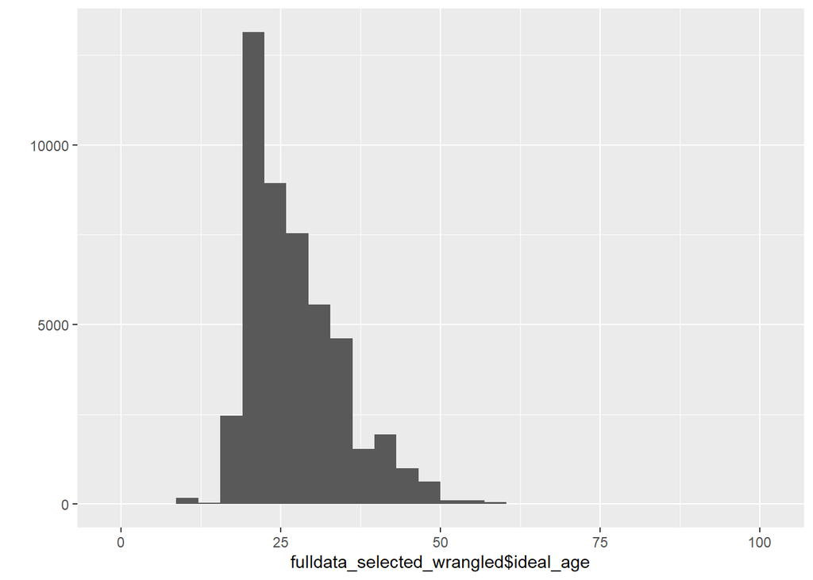

```r
qplot(fulldata_selected_wrangled$ideal_age)
```

```r
sum(fulldata_selected_wrangled$ideal_age > 100, na.rm = T)
```

```
## [1] 0
```

```r
fulldata_selected_wrangled = fulldata_selected_wrangled %>%
  mutate(ideal_age = ifelse(ideal_age > 100, NA, ideal_age))

table(is.na(fulldata_selected_wrangled$ideal_age))
```

```
##
## FALSE  TRUE
## 47873 46865
```

```r
fulldata_selected_wrangled %>%
  select(ideal_age) %>%
  lapply(table)
```

```
## $ideal_age
##
##    0   10   11   12   13   14   15   16   17   18   19   20   21   22   23   24
##    1  161    4   12    5   12   25   82  197 2184 2996 4294 2805 3040 2811 2238
##   25   26   27   28   29   30   31   32   33   34   35   36   37   38   39   40
## 3879 2031 1939 2497 1076 3399  685 1463 1069  679 2183  674  507  796  240 1179
##   41   42   43   44   45   46   47   48   49   50   51   52   53   54   55   56
##  142  350  266  173  698  134  116  174   51  288   24   56   32   15   77   15
##   57   58   59   60   62   64   65   67   68   69   70   71   75   77   80   85
##   10   15    3   24    6    2    6    2    3    2    3    2    1    1    1    1
##   88   90   92   96   98   99  100
##    1    1    1    1    1    1   11
```

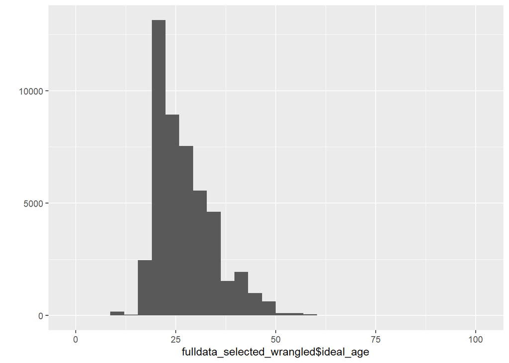

```r
qplot(fulldata_selected_wrangled$ideal_age)
```

## Importance Height

Item should range from 0 to 6

```r
fulldata_selected_wrangled %>%
  select("imp_height") %>%
  lapply(table)
```

```
## $imp_height
##
##     0     1     2     3     4     5     6
##  4577  2763  5069  9928 15262  9445  5846
```

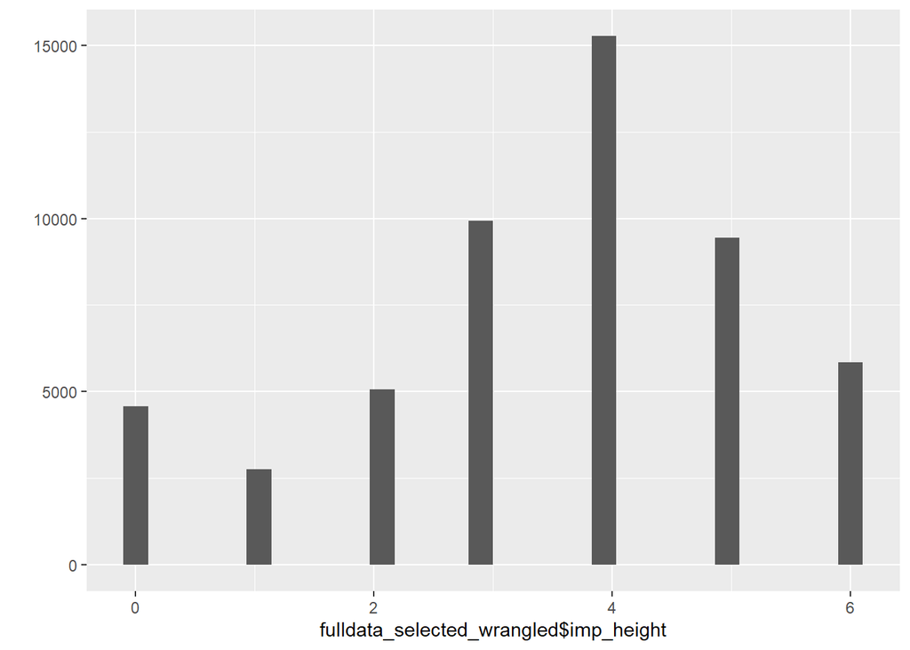

```r
qplot(fulldata_selected_wrangled$imp_height)
```

##Ideal Height Item has the options: much shorter than me, shorter than me, around the same height as me, taller than me, much taller than me

```r
table(fulldata_selected_wrangled$ideal_height)
```

```
##
##                              around the same height as me
##                        46295                         5741
##         much shorter than me          much taller than me
##                           98                         4546
##              shorter than me               taller than me
##                          940                        37118
```

```r
fulldata_selected_wrangled = fulldata_selected_wrangled %>%
  mutate(ideal_height = ifelse(ideal_height == "", NA, ideal_height),
         ideal_height_numeric = as.factor(ideal_height))

fulldata_selected_wrangled$ideal_height_numeric =
  recode(fulldata_selected_wrangled$ideal_height_numeric,
         'much shorter than me' = -2,'shorter than me' = -1,
         'around the same height as me' = 0, 'taller than me' = 1,
         'much taller than me' = 2, .default = NULL, .missing = NULL)

crosstabs(~ideal_height_numeric + ideal_height, data = fulldata_selected_wrangled)
```

```
##                     ideal_height
## ideal_height_numeric around the same height as me much shorter than me
##                 -2                              0                   98
##                 -1                              0                    0
##                 0                            5741                    0
##                 1                               0                    0
##                 2                               0                    0
##                 <NA>                            0                    0
##                     ideal_height
## ideal_height_numeric much taller than me shorter than me taller than me  <NA>
##                 -2                     0               0              0     0
##                 -1                     0             940              0     0
##                 0                      0               0              0     0
##                 1                      0               0          37118     0
##                 2                   4546               0              0     0
##                 <NA>                   0               0              0 46295
```

```r
table(fulldata_selected_wrangled$ideal_height)
```

```
##
## around the same height as me         much shorter than me
##                         5741                           98
##          much taller than me              shorter than me
##                         4546                          940
##               taller than me
##                        37118
```

```r
class(fulldata_selected_wrangled$ideal_height_numeric)
```

```
## [1] "numeric"
```

```r
levels(fulldata_selected_wrangled$ideal_height_numeric)
```

[output not shown]

```r
fulldata_selected_wrangled %>%
  select("ideal_height_numeric") %>%
  lapply(table)
```

```
## $ideal_height_numeric
##
##    -2    -1     0     1     2
##    98   940  5741 37118  4546
```

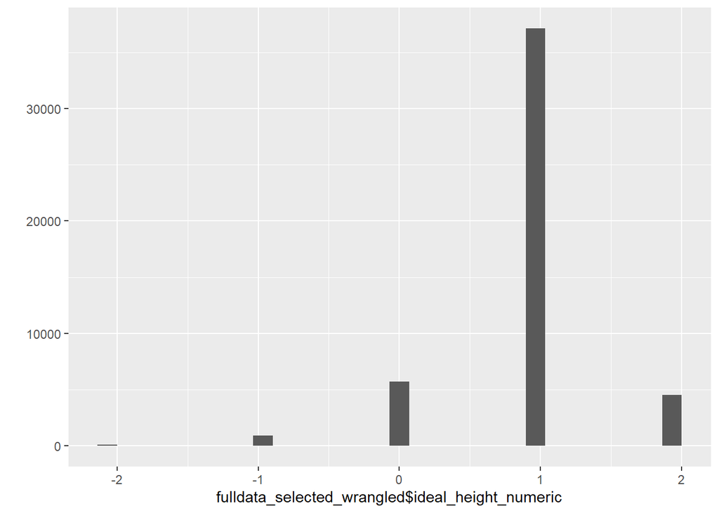

```r
qplot(fulldata_selected_wrangled$ideal_height_numeric)
```

```r
fulldata_selected_wrangled = fulldata_selected_wrangled %>%
  mutate(ideal_height = ideal_height_numeric) %>%
  select(-ideal_height_numeric)
```

### Country

```r
x = table(fulldata_selected_wrangled$country)
table(is.na(fulldata_selected_wrangled$country))
```

```
##
## FALSE
## 94738
```

#### Problem with South Korea / Korea, South

```r
fulldata_selected_wrangled = fulldata_selected_wrangled %>%
  mutate(country = ifelse(country == "Korea, South",
                          "South Korea",
                          country),
         country = ifelse(country == "Congo, Democratic Republic of the",
                          "Congo, Republic of the",
                          country))
```

### Language

Chinese, Danish, English, French, German, Japanese, Portuguese, Russian, Spanish, Italian

```r
table(fulldata_selected_wrangled$language)
```

```
##
##    chinese     danish    english     french     german    italian   japanese
##        441       2316      24387      18483      13346       6512       1577
## portuguese    russian    spanish
##       6450       1455      19771
```

```r
table(is.na(fulldata_selected_wrangled$country))
```

```
##
## FALSE
## 94738
```

### Sex

Categories: Woman; Genderqueer/Nonbinary; Man; None of the above; Prefer not to say; Other

```r
table(fulldata_selected_wrangled$sex)
```

```
##
##                       Genderqueer/Nonbinary                   Man
##                 26638                   840                  2055
##     None of the above                 Other     Prefer not to say
##                    58                    43                   225
##                 Woman
##                 64879
```

```r
# Set missing values as NA
fulldata_selected_wrangled = fulldata_selected_wrangled %>%
  mutate(sex = as.character(sex),
         sex = ifelse(sex == "", NA, sex),
         sex = factor(sex))

table(fulldata_selected_wrangled$sex)
```

```
##
## Genderqueer/Nonbinary                   Man     None of the above
##                   840                  2055                    58
##                 Other     Prefer not to say                 Woman
##                    43                   225                 64879
```

```r
table(is.na(fulldata_selected_wrangled$sex))
```

```
##
## FALSE  TRUE
## 68100 26638
```

### Sexual Orientation

heterosexual; Lesbian/Gay/Homosexual; Bisexual/Pansexual; Queer; Asexual; Prefer not to say; Other

```r
table(fulldata_selected_wrangled$sexual_orientation)
```

```
##
##                                       Asexual     Bisexual/Pansexual
##                  26638                    562                   9605
## Lesbian/Gay/Homosexual                  Other      Prefer not to say
##                   1508                    313                    634
##                  Queer  Straight/Heterosexual
##                    832                  54646
```

```r
# Set missing values as NA
fulldata_selected_wrangled = fulldata_selected_wrangled %>%
  mutate(sexual_orientation = as.character(sexual_orientation),
         sexual_orientation = ifelse(sexual_orientation == "", NA, sexual_orientation),
         sexual_orientation = factor(sexual_orientation))

table(fulldata_selected_wrangled$sexual_orientation)
```

```
##
##                Asexual     Bisexual/Pansexual Lesbian/Gay/Homosexual
##                    562                   9605                   1508
##                  Other      Prefer not to say                  Queer
##                    313                    634                    832
##  Straight/Heterosexual
##                  54646
```

```r
table(is.na(fulldata_selected_wrangled$sexual_orientation))
```

```
##
## FALSE  TRUE
## 68100 26638
```

### Relationship Variable

```r
table(fulldata_selected_wrangled$relationship) #No romantic or sexual relationships during the past 3 months
```

```
##
## False  True
## 78064 16674
```

```r
table(fulldata_selected_wrangled$relationship1) #Other
```

```
##
## False  True
## 94434   304
```

```r
table(fulldata_selected_wrangled$relationship2) #Short-term (casual) sexual relationship (e.g. hookups or one-night-stands)
```

```
##
## False  True
## 88348  6390
```

```r
table(fulldata_selected_wrangled$relationship3) #New (less than 1 month old) romantic and/or sexual relationship
```

```
##
## False  True
## 89708  5030
```

```r
table(fulldata_selected_wrangled$relationship4) #Ongoing (longer than 1 month) uncommitted/non-exclusive romantic and/or sexual relationship
```

```
##
## False  True
## 85838  8900
```

```r
table(fulldata_selected_wrangled$relationship5)#Long-term committed/exclusive sexual relationship with one or more partners
```

```
##
## False  True
## 63392 31346
```

```r
fulldata_selected_wrangled = fulldata_selected_wrangled %>%
  mutate(relationship = ifelse(relationship == "True",
                               "No romantic or sexual relationships during the past 3 months, ",
                               ""),
         relationship = ifelse(relationship1 == "True",
                               paste(relationship,
                                     "Other, "),
                               relationship),
         relationship = ifelse(relationship2 == "True",
                               paste(relationship,
                                     "Short-term (casual) sexual relationship (e.g. hookups or one-night-stands), "),
                               relationship),
         relationship = ifelse(relationship3 == "True",
                               paste(relationship,
                                     "New (less than 1 month old) romantic and/or sexual relationship, "),
                               relationship),
         relationship = ifelse(relationship4 == "True",
                               paste(relationship,
                                     "Ongoing (longer than 1 month) uncommitted/non-exclusive romantic and/or sexual relationship, "),
                               relationship),
         relationship = ifelse(relationship5 == "True",
                               paste(relationship,
                                     "Long-term committed/exclusive sexual relationship with one or more partners, "),
                               relationship),
         relationship = ifelse(relationship == "", NA, relationship))

table(fulldata_selected_wrangled$relationship)
```

[output not shown]

[output cut: 74 more lines]

```r
# Check whether command worked correctly
table(fulldata_selected_wrangled$relationship %contains% "No romantic or sexual relationships during the past 3 months")
```

```
##
## FALSE  TRUE
## 48257 16674
```

### Answer accuracy

I took the survey seriously; please use my information in the study.; I did not answer seriously, please disregard my information; I choose not to answer

```r
table(fulldata_selected_wrangled$answer_accuracy)
```

```
##
##
##                                                                33689
##                                              I choose not to answer.
##                                                                 1336
##         I did not answer seriously; please disregard my information.
##                                                                  734
## I took the survey seriously; please use my information in the study.
##                                                                58979
```

```r
# Set missing values as NA
fulldata_selected_wrangled = fulldata_selected_wrangled %>%
  mutate(answer_accuracy = as.character(answer_accuracy),
         answer_accuracy = ifelse(answer_accuracy == "", NA, answer_accuracy),
         answer_accuracy = factor(answer_accuracy))

table(fulldata_selected_wrangled$answer_accuracy)
```

```
##
##                                              I choose not to answer.
##                                                                 1336
##         I did not answer seriously; please disregard my information.
##                                                                  734
## I took the survey seriously; please use my information in the study.
##                                                                58979
```

```r
table(is.na(fulldata_selected_wrangled$answer_accuracy))
```

```
##
## FALSE  TRUE
## 61049 33689
```

```r
fulldata_selected_wrangled %>%
  select(sex, answer_accuracy) %>%
  md_pattern()
```

```
## # A tibble: 4 x 5
##   description                     sex answer_accuracy var_miss n_miss
##   <chr>                         <dbl>           <dbl>    <dbl>  <dbl>
## 1 Missing values in 0 variables     1               1        0  61049
## 2 Missing values per variable   26638           33689    60327  60327
## 3 Missing values in 2 variables     0               0        2  26638
## 4 Missing values in 1 variables     1               0        1   7051
```

## Creating new variables for Ideal Partner Preferences

```r
fulldata_selected_wrangled = fulldata_selected_wrangled %>%
  mutate(pref_level_kind_supportive = (pref_level_kind + pref_level_supportive)/2,
         pref_level_attractiveness = (pref_level_attractive_body +
                                        pref_level_attractive_face)/2,
         pref_level_financially_secure_successful_ambitious = (pref_level_financially_secure + pref_level_successful_ambitious)/2,
         pref_level_confident_assertive = (pref_level_confident + pref_level_assertive)/2,
         pref_level_intelligence_educated = (pref_level_intelligence + pref_level_educated)/2)

table(fulldata_selected_wrangled$pref_level_kind_supportive)
```

```
##
##     1   1.5     2   2.5     3   3.5     4   4.5     5   5.5     6
##     5     5    27    86   346  1276  4385  9485 15801 15765 16482
```

```r
table(fulldata_selected_wrangled$pref_level_attractiveness)
```

```
##
##     0   0.5     1   1.5     2   2.5     3   3.5     4   4.5     5   5.5     6
##    26    38   294   514  1429  2353  8528  9893 15006 10768  7628  2884  1973
```

```r
table(fulldata_selected_wrangled$pref_level_financially_secure_successful_ambitious)
```

```
##
##     0   0.5     1   1.5     2   2.5     3   3.5     4   4.5     5   5.5     6
##    15    22    77   236   755  1812  4958  9082 13177 12733 10168  5313  3337
```

```r
table(fulldata_selected_wrangled$pref_level_confident_assertive)
```

```
##
##     0   0.5     1   1.5     2   2.5     3   3.5     4   4.5     5   5.5     6
##     1     5    22   106   329  1110  4433  9205 14201 13471 11027  6166  3461
```

```r
table(fulldata_selected_wrangled$pref_level_intelligence_educated)
```

```
##
##     0   0.5     1   1.5     2   2.5     3   3.5     4   4.5     5   5.5     6
##     4     5    21    71   186   532  2196  4916 10967 12853 14678  8858  7989
```

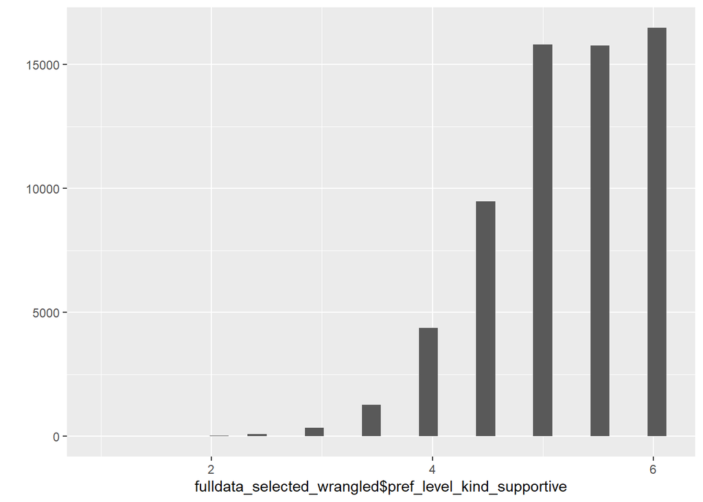

```r
qplot(fulldata_selected_wrangled$pref_level_kind_supportive)
```

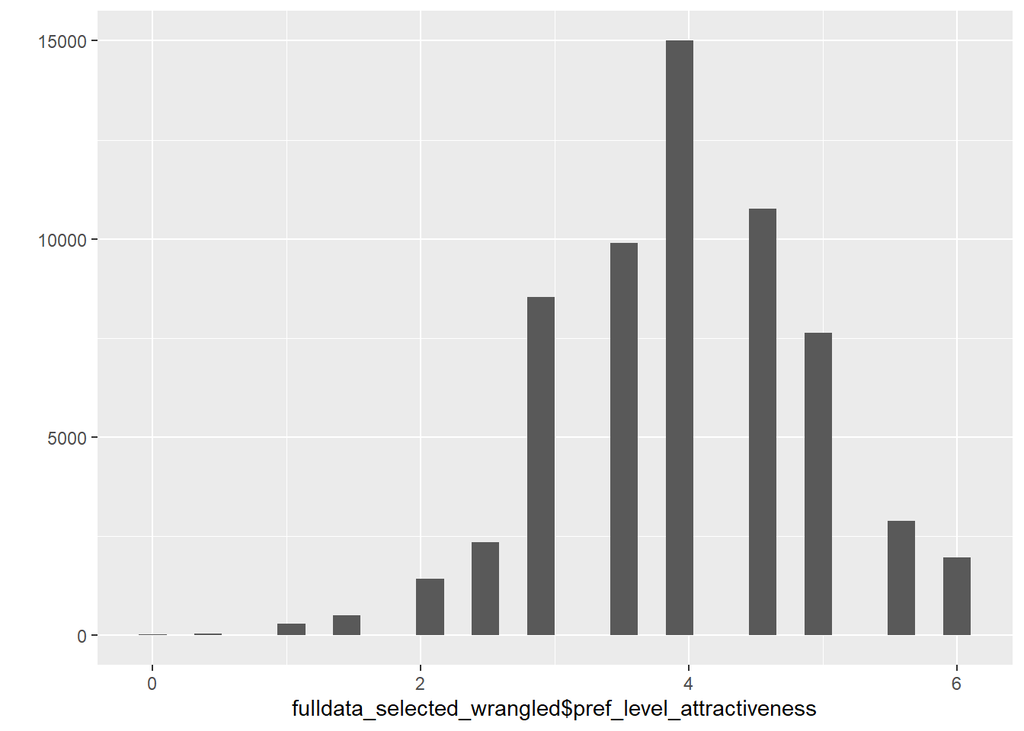

```r
qplot(fulldata_selected_wrangled$pref_level_attractiveness)
```

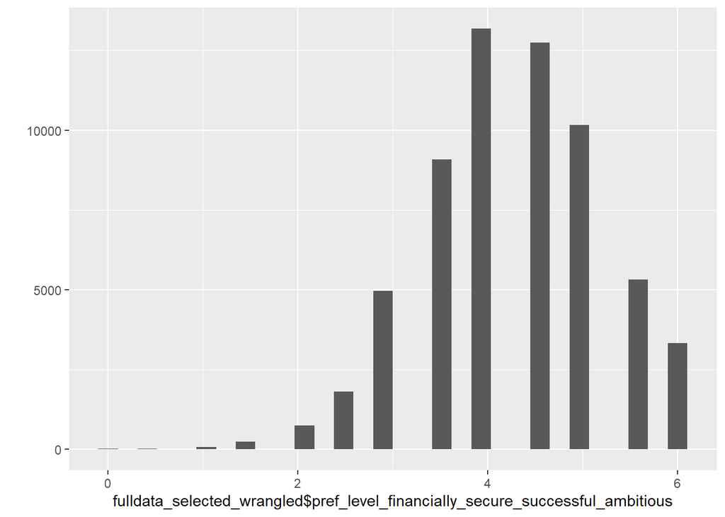

```r
qplot(fulldata_selected_wrangled$pref_level_financially_secure_successful_ambitious)
```

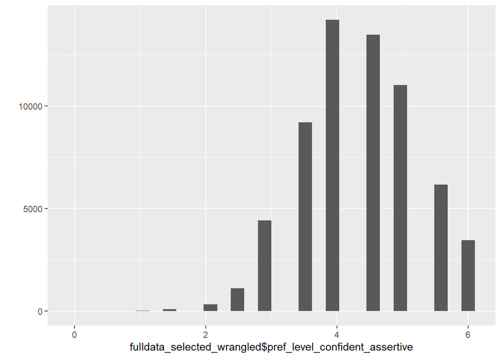

```r
qplot(fulldata_selected_wrangled$pref_level_confident_assertive)
```

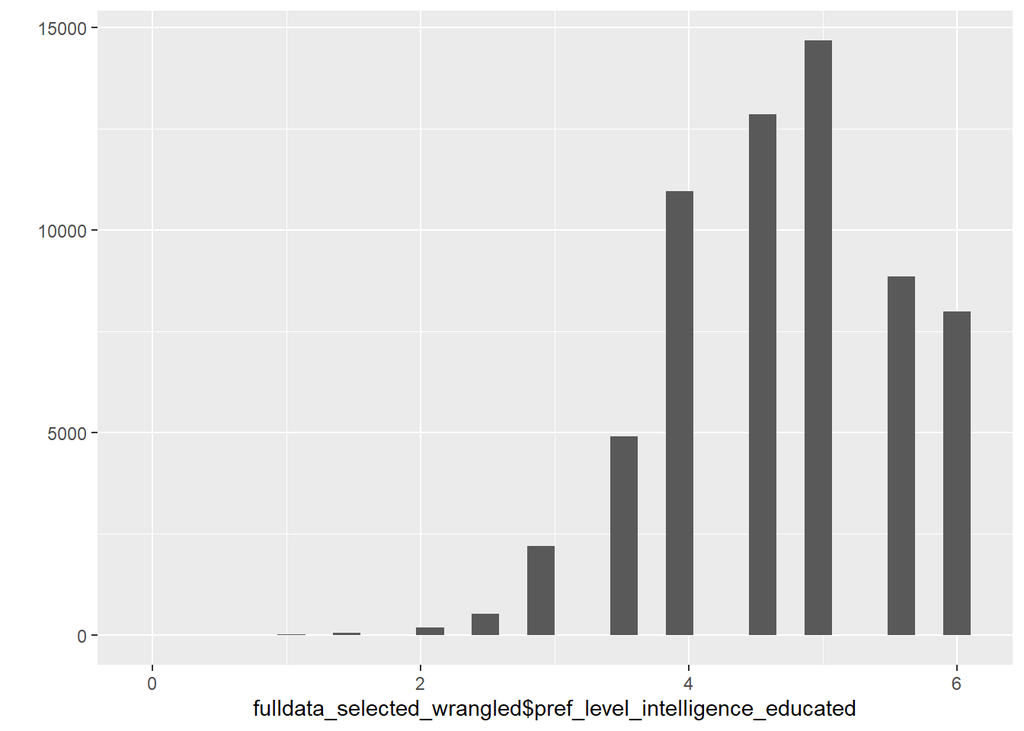

```r
qplot(fulldata_selected_wrangled$pref_level_intelligence_educated)
```

## Save Data

```r
write.csv(fulldata_selected_wrangled, file = "fulldata_selected_wrangled.csv")
```